# individual1

Maddie Mueller

4/14/2021

# Lab 5

# Individual 1 - Madalyn Mueller

```r
#All defaults
library(tidyverse)
#All defaults
acc <- read.csv("https://raw.githubusercontent.com/xdaiISU/ds202materials/master/hwlabs/fars2017/accident.csv", stringsAsFactors = FALSE)

per <- read.csv("https://raw.githubusercontent.com/xdaiISU/ds202materials/master/hwlabs/fars2017/person.csv", stringsAsFactors = FALSE)
```

## 1) Are there some days of the week where more accidents happen than the others (see FARS manual, use variable DAY_WEEK)?

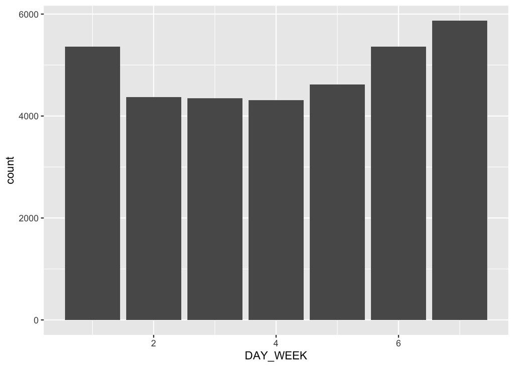

```r
#All defaults
ggplot(acc, aes(x=DAY_WEEK)) + geom_bar()
```

## 2) Create a data frame containing the persons who are fatally hurt in the accidents (look up variable INJ_SEV)

```r
#All defaults
fatal_inj <- per %>%
  filter(INJ_SEV == 4)
print(fatal_inj)
```

```
##      STATE ST_CASE VE_FORMS VEH_NO PER_NO STR_VEH COUNTY DAY MONTH HOUR MINUTE
## 1        1   10001        1      1      1       0     73  19     2   23     35
## 2        1   10002        1      1      1       0     89  14     2   14     59
## 3        1   10003        3      2      1       0    101  31     1   20     31
## 4        1   10004        1      1      1       0     73   1     1   16     55
## 5        1   10005        1      1      1       0     13   1     1   20      0
## 6        1   10006        2      1      1       0     49   6     1   18     40
## 7        1   10007        2      1      1       0     73  11     1   17     57
## 8        1   10008        1      1      1       0      3  11     1   16     50
## 9        1   10009        1      1      1       0     87  11     1   14     30
## 10       1   10011        2      1      1       0     87  15     1    4     35
## 11       1   10011        2      2      1       0     87  15     1    4     35
## 12       1   10012        2      1      1       0     85  19     1   21     50
## 13       1   10013        2      1      1       0     83   1     1   18     34
## 14       1   10013        2      1      2       0     83   1     1   18     34
```

[output cut: 11754 more lines]

## 3) Create a data frame containing the most dangerous vehicle make in each state. The number of persons fatally hit in the vehicle make is used to assess the (non-)safety of a make. Make sure to handle the missing values appropriately. (look up variable MAKE)

```r
#All defaults
danger_car <- fatal_inj %>%
  drop_na(MAKE) %>%
  group_by(STATE, MAKE) %>%
  summarize(count = n()) %>%
  group_by(STATE) %>%
  filter(count==max(count))
danger_car
```

```
## # A tibble: 54 x 3
## # Groups:   STATE [51]
##    STATE  MAKE count
##    <int> <int> <int>
##  1     1    12   138
##  2     2    12     9
##  3     4    20    88
##  4     5    20    88
##  5     6    49   351
##  6     8    12    63
##  7     8    37    63
##  8     9    37    28
##  9    10    37    12
## 10    11    37     5
## # … with 44 more rows
```

## 4) Create a map, and label each state with the most dangerous vehicle. Discuss the definition of the most dangerous vehicle, and what you find from the map. (Hint: Read the description for the STATE and COUNTY columns in the FARS manual. The state & county codes are Geographic Locator Codes (GLCs) from the General Services Administration’s (GSA) publication. Use readxl::read_xlsx to read in the GLCs.)

[figure not shown]

```r
#All defaults
accper <- inner_join(acc, per, by ="ST_CASE")
fatal_accper <- accper %>%
  filter(INJ_SEV == 4)
ggplot(fatal_accper, aes(x=LONGITUD, y=LATITUDE, fill=MAKE)) + geom_polygon(aes(group=STATE.x))
```

## 5) Join the accident and person table (work out which variable(s) to use)

```r
#All defaults
accper <- inner_join(acc, per, by ="ST_CASE")
```

## 6) Tally the number of accidents by day of the week (DAY_WEEK), hour of the day (HOUR) and gender (SEX). Visualize the results and explain what you find.

```r
#All defaults
acc %>%
  group_by(DAY_WEEK) %>%
  count(DAY_WEEK)
```

```
## # A tibble: 7 x 2
## # Groups:   DAY_WEEK [7]
##   DAY_WEEK     n
##      <int> <int>
## 1        1  5360
## 2        2  4374
## 3        3  4347
## 4        4  4314
## 5        5  4621
## 6        6  5358
## 7        7  5873
```

It looks like the most accidents happen on Saturdays, followed by Sundays and Fridays. The least amount of accidents happen on Wednesdays, which makes sense because it is in the middle of the week when there usually isn’t a lot going on.

```r
#All defaults
acc %>%
  group_by(HOUR) %>%
  count(HOUR)
```

```
## # A tibble: 25 x 2
## # Groups:   HOUR [25]
##     HOUR     n
##    <int> <int>
##  1     0  1321
##  2     1  1177
##  3     2  1241
##  4     3   957
##  5     4   813
##  6     5  1065
##  7     6  1282
##  8     7  1162
##  9     8   945
## 10     9   929
## # … with 15 more rows
```

It looks like the most accidents happened around 6:00 p.m. This makes sense because that is when most people are coming home from work on the weekdays or going out to dinner/drinks/events on the weekends.

```r
#All defaults
per %>%
  group_by(SEX) %>%
  count(SEX)
```

```
## # A tibble: 4 x 2
## # Groups:   SEX [4]
##     SEX     n
##   <int> <int>
## 1     1 55230
## 2     2 28149
## 3     8   473
## 4     9  1069
```

Males have twice the amount of accidents that females have. This is surprising to me, I figured the numbers would be more even. Males must be more of reckless drivers.

## 7) Now plot a choropleth map of the number of deaths on a county level. Also explain what you find.

[figure not shown]

```r
#All defaults
fatal_accper <- accper %>%
  filter(INJ_SEV == 4)
ggplot(fatal_accper, aes(x=LONGITUD, y=LATITUDE, fill=INJ_SEV)) + geom_polygon(aes(group=COUNTY.x))
```

## 8) Is summer or winter more dangerous? Does this depend on states? Explore and explain.

```r
#All defaults
summerdeath <- acc %>%
  filter(MONTH >= 6 | MONTH <= 8) %>%
  select(STATE, FATALS) %>%
  group_by(STATE) %>%
  summarize(sumCount = sum(FATALS))

winterdeath <- acc %>%
  filter(MONTH >= 11 | MONTH <= 2) %>%
  select(STATE, FATALS) %>%
  group_by(STATE) %>%
  summarize(winCount = sum(FATALS))

summerdeath
```

```
## # A tibble: 51 x 2
##    STATE sumCount
##    <int>    <int>
##  1     1      948
##  2     2       79
##  3     4     1000
##  4     5      493
##  5     6     3602
##  6     8      648
##  7     9      278
##  8    10      119
##  9    11       31
## 10    12     3112
## # … with 41 more rows
```

```r
winterdeath
```

```
## # A tibble: 51 x 2
##    STATE winCount
##    <int>    <int>
##  1     1      286
##  2     2       28
##  3     4      323
##  4     5      147
##  5     6     1171
##  6     8      180
##  7     9       89
##  8    10       39
##  9    11       10
## 10    12     1090
## # … with 41 more rows
```

```r
totalsummer <- sum(summerdeath$sumCount)
totalsummer
```

```
## [1] 37133
```

```r
totalwinter <- sum(winterdeath$winCount)
totalwinter
```

```
## [1] 11496
```